# Alisal Union Dashboard DA Summary

## Report Purpose

This report is created to assist Alisal Union in reflecting on the student groups whose indicators led to Differentiated Assistance.

The graphic below shows the color for each student group for each indicator from the [California Dashboard 2025](https://www.caschooldashboard.org/reports/27659610000000/2025)

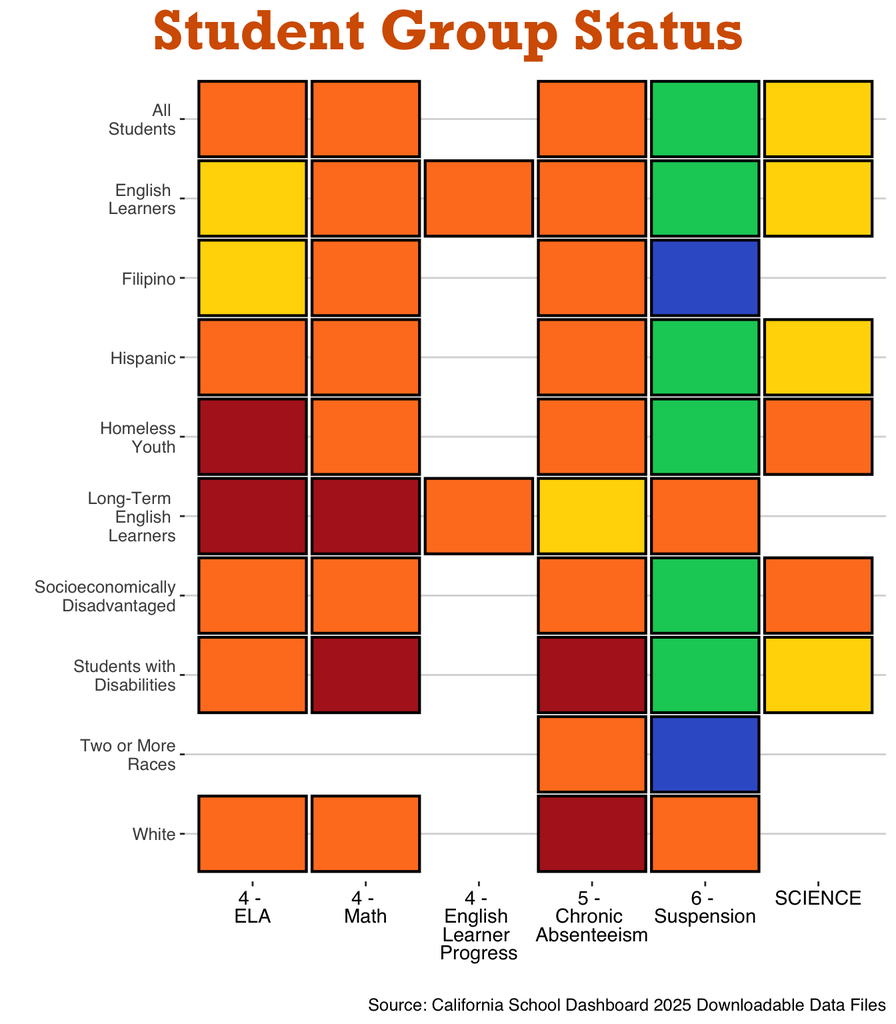

## Qualifying Groups

Differentiated Assistance is determined by the California Dashboard.

The table below displays which student groups qualified Alisal Union to be eligible for [Differentiated Assistance](https://www.cde.ca.gov/ta/ac/cm/leaproposedcrit.asp) by meeting the criteria for two or more LCFF priority areas according to California Education Code Section 52071(c). [California’s System of Support](https://www.cde.ca.gov/sp/sw/t1/csss.asp). The table shows for each student group which Priority Areas and associated indicators met qualification criteria.

| Student Group | Qualifying Priority Areas |
| --- | --- |
| Students with Disabilities | Met Criteria in Priority Areas 4 (Academic Indicators) and 5 (Chronic Absenteeism and/or Graduation) |

## Status Details for all Indicators

These graphs represent all of the indicators from the Dashboard and show how each of the student groups performed. The light grey arrows represent change from the prior year. Arrows pointing to the right increased and to the left decreased, and the longer the tail length the greater the change.

**Click here to display graphs**

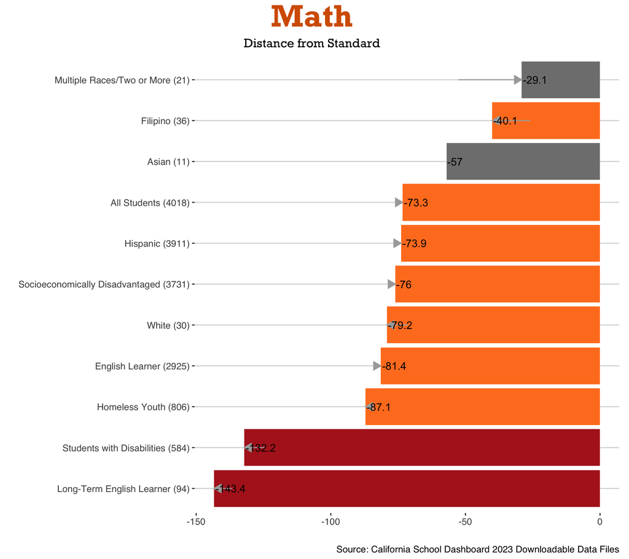

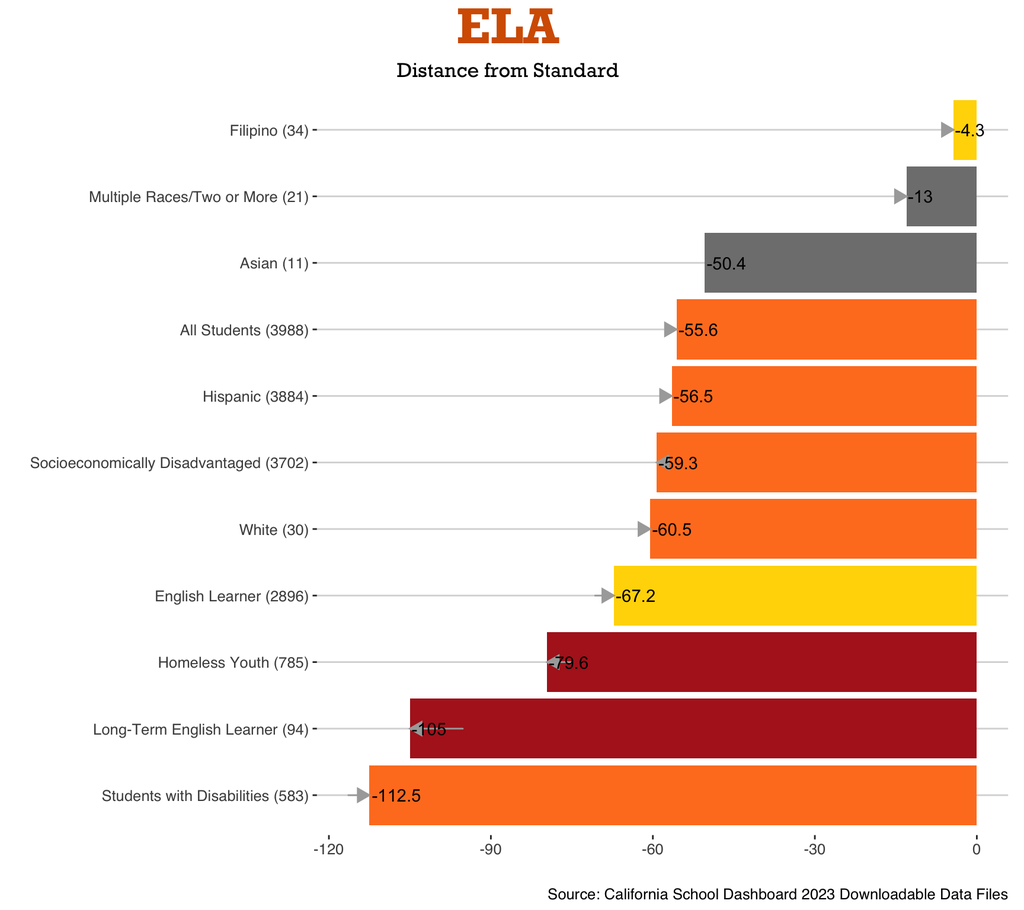

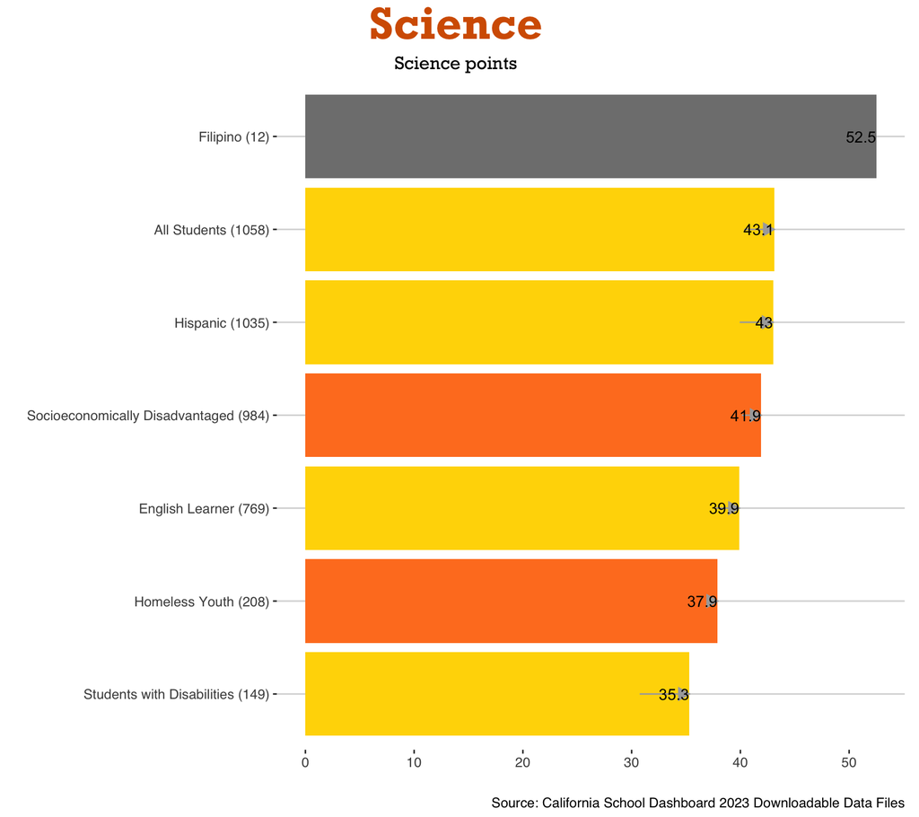

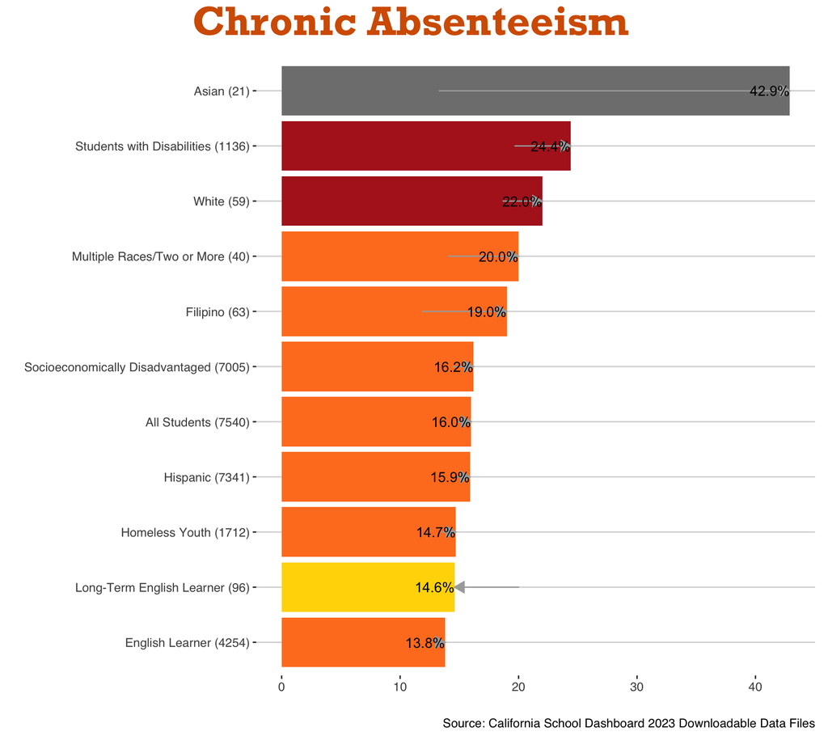

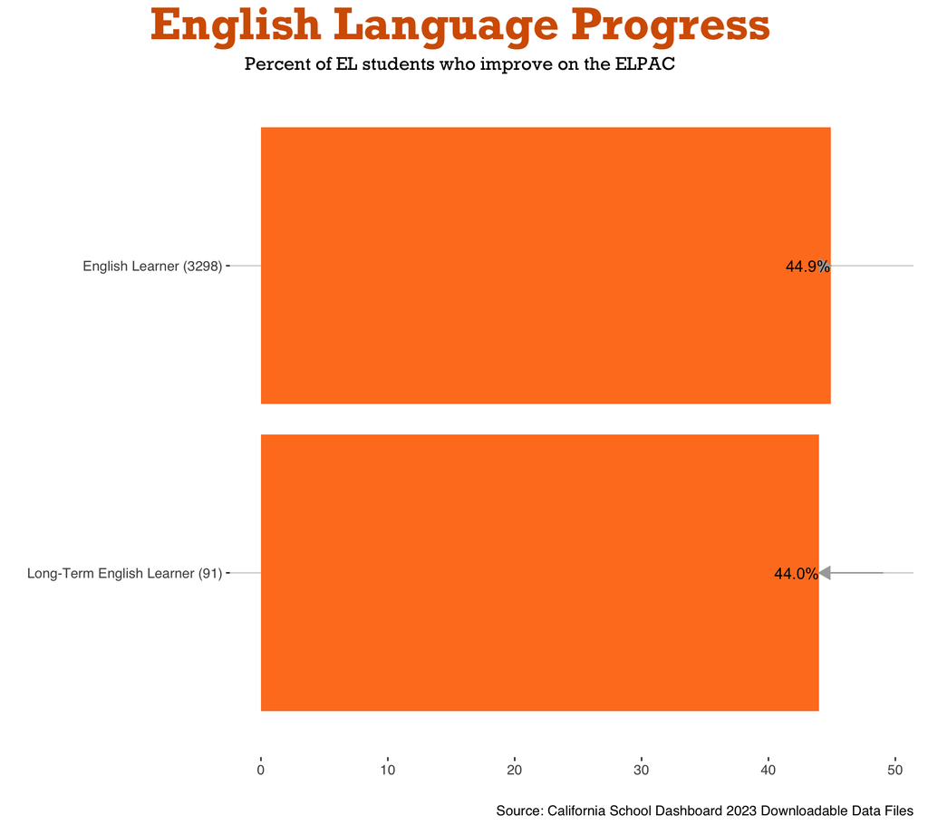

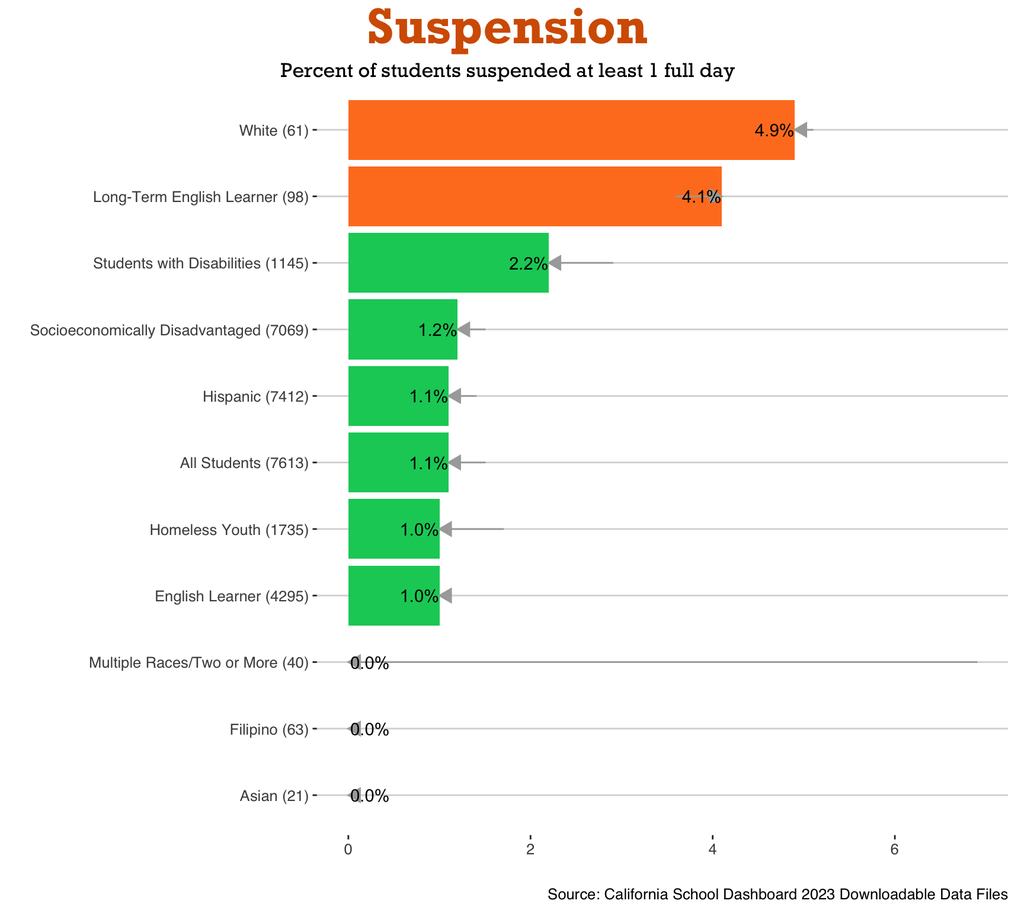

## Historical Confetti

These graphs represent all of the indicators from Priority Areas that qualified the district. They included all qualifying subgroups on each graph, whether this was a qualifying indicator or not, as well as the All Students group for comparisons.

**Click here to display graphs**

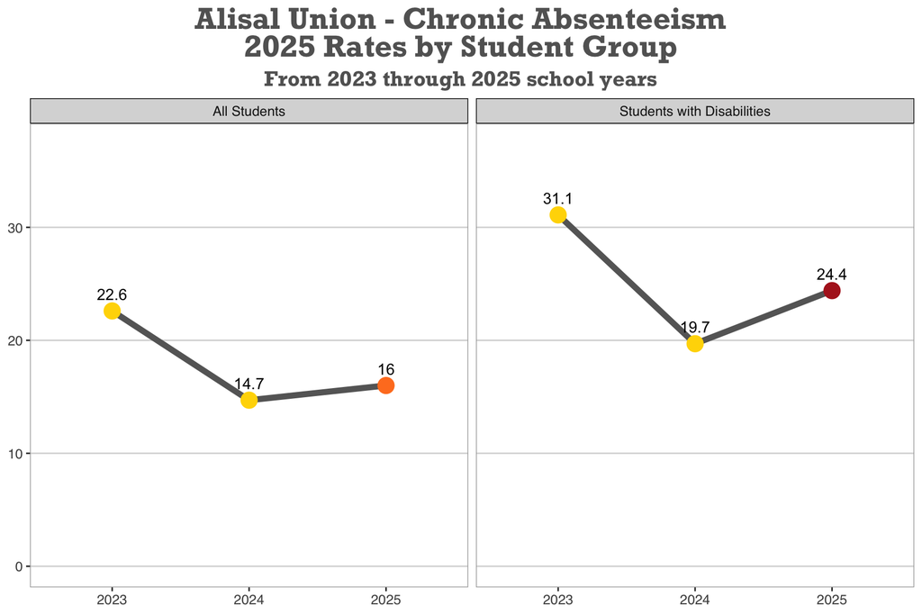

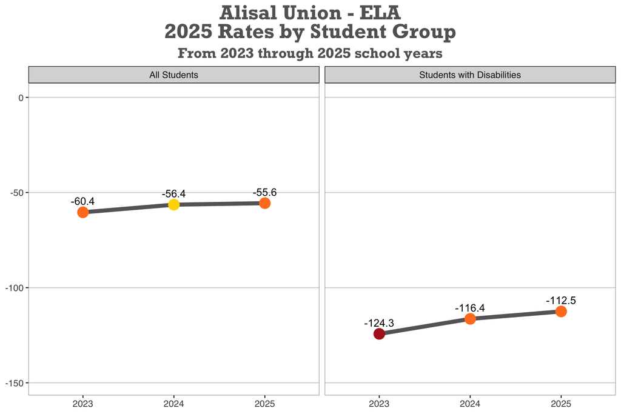

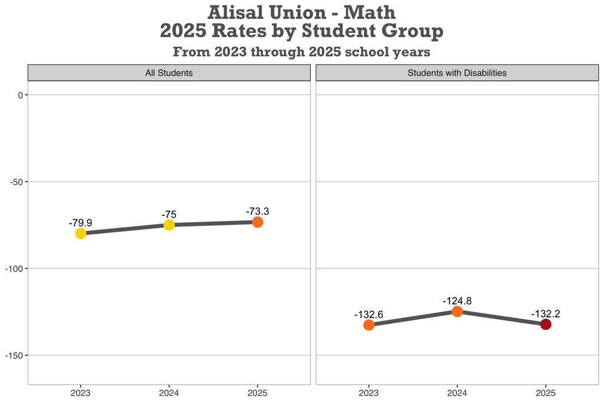

## Status Needed to Achieve Orange in 2026

This section estimates the limits for indicators that are Red in 2025 to receive an orange or higher color next year on the 2026 Dashboard. The thresholds below are based on the [5x5 grids last approved by the State Board of Education](https://www.cde.ca.gov/ta/ac/cm/fivebyfivecolortables19.asp#AcademicTable) and the number of students in the 2025 calculation. State policies may change and the student counts may shift.

| Student Group | Indicator | Current Status | Target Status for Orange | Change Needed | Number of Students (as applicable) |
| --- | --- | --- | --- | --- | --- |
| Students with Disabilities | CHRO | 24.4 | 23.9 | -0.5 | 271 |
| White | CHRO | 22 | 21.5 | -0.5 | 12 |
| Homeless Youth | ELA | -79.6 | -76.6 | 3 |  |
| Long-Term English Learner | ELA | -105 | -102 | 3 |  |
| Long-Term English Learner | MATH | -143.4 | -140.4 | 3 |  |
| Students with Disabilities | MATH | -132.2 | -129.2 | 3 |  |

**Click here to display sentences**

This report was generated at 2025-12-01.

It was developed by [David Dobrowski](https://github.com/dobrowski) at the [Monterey County Office of Education](https://www.montereycoe.org/)